# Effects of Loan Features on The Loan Amount

## Investigation Overview

In this investigation, I am interested in finding out the features that can be used to best predict the LoanOriginalAmount feature. The main focus was on the credit score, income range, whether borrower income was verifiable, and whether the borrower was a home owner.

## Dataset Overview

Initially, the dataset consisted of 113,937 loans with 81 features, including loan amount, credit score, income range and many other features. Part of the the dataset was removed because of missing values, duplicated loankeys, incorrect data, and outliers. In the end, the remaining data is 81857 rows and 81 columns.

## Distribution of LoanOriginalAmount

The loan amount feature initially had a long tail starting from a minimum of USD 1,000) to a maximum of USD 36,000. After dealing with the outliers the tail shortened to about USD 27,000. Plotted on a logarithmic scale, the distribution has a multi-modal shape.

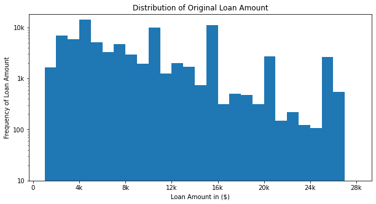

## Distribution of CreditScoreRangeLower

The credit score feature initially had a short tail starting from a minimum of 600 to a maximum of 850. After dealing with the outliers the tail shortened to about 810. This score comes from an external credit agency to show the credibility of the borrower in terms of paying their loans.

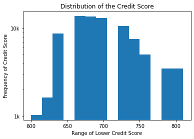

## Correlations Among Features of Interest

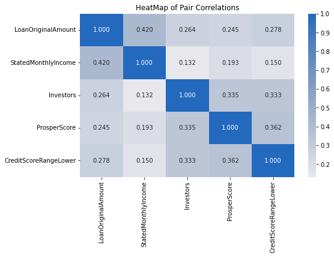

## Original Loan Amount Against Income Range

The income range is the one that is the highest predictor of the loan amount. The higher the income range, the higher the loan amount. The lowest income range \$1-24,999) has an average loan amount of \\$4300, \$25,000-49,000 has an average loan amount of \\$6435, \$50,000-74,999 has an average of \\$9000, \$75,000-99,999 has an average of \\$10622, and \$100+ has an average of \\$12850.

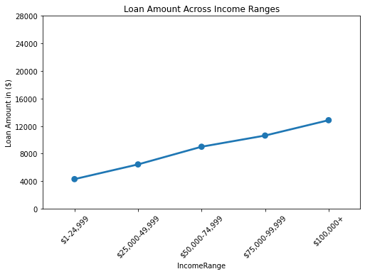

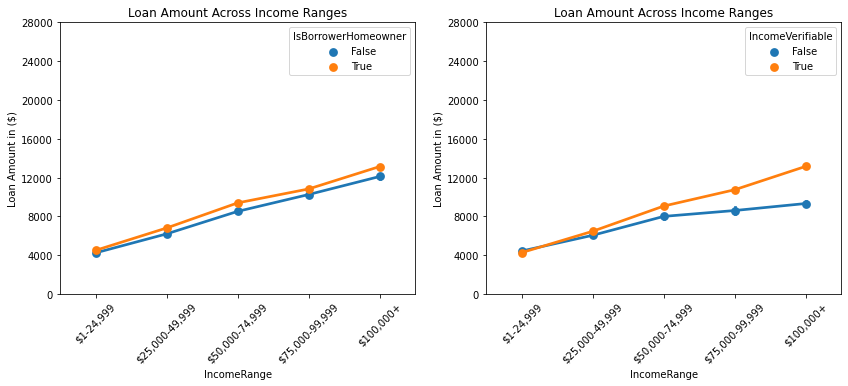